# ETC3250/5250 IML Asignment 1 Solution

Thanh Van Tran - 32678479

2023-04-03

```r
# Load the packages that you will use to complete this assignment.
library(tidyverse)
library(ggplot2)
library(GGally)
library(rsample)
library(glmnet)
library(dplyr)
library(yardstick)
library(tidymodels)
library(lubridate)
library(stats)
library(ggplotify)
library(gridExtra)
```

## A. Preliminary analysis

*1. Load your downloaded data into R as a `tibble` object, ensuring each variable is encoded appropriately, and display the first 10 rows of your data set.* **(1 mark)**

INCLUDE YOUR ANSWER HERE

```r
#INCLUDE YOUR R CODE HERE
data32678479 <-
  read_csv("/Users/thanhvantran/Desktop/Assignment1_ThanhVanTran_32678479/data32678479.csv")
mydata <- as_tibble(data32678479)
mydata$id <- as.character(mydata$id)
mydata$type <- as.factor(mydata$type)
head(mydata, 10)
```

```
## # A tibble: 10 × 12
##    id    open_date type     P1    P2    P3    P4    P5    P6    P7    P8 revenue
##    <chr> <chr>     <fct> <dbl> <dbl> <dbl> <dbl> <dbl> <dbl> <dbl> <dbl>   <dbl>
##  1 87895 12/12/20… IL        5     3     2     3     5     4   2       5  1.29e7
##  2 42772 12/17/20… IL        5     3     1     1     5     4   7.5     3  1.84e7
##  3 75893 10/04/20… IL        5     2     3     2     5     1   3       5  2.07e7
##  4 19120 04/12/20… IL       10     6     2     2     8     2   7.5     4  1.36e7
##  5 15290 01/17/20… IL       10     2     1     2     5     2   5       4  1.67e7
##  6 35737 12/28/20… IL        4     1     5     5     5     2   3       4  1.39e7
##  7 43194 09/13/19… IL        5     2     1     1     8     5   3       4  1.45e7
##  8 78358 06/16/20… FC        5     3     1     4     8     2   7.5     5  1.29e7
##  9 73962 12/07/20… IL        5     5     1     1    10     4   3       8  1.40e7
## 10 54131 07/14/20… FC        5     4     1     3    10     4   3       5  1.40e7
```

*2. Construct a new variable called `age` that corresponds to the age of the restaurant (in years) at 1st January, 2015. Show the histogram of this `age` variable.* **(1 mark)**

INCLUDE YOUR ANSWER HERE

The age of the restaurant are not rounded up to ensure the accuracy of the coefficient and the predicted value in case variable “age” is included in the model.

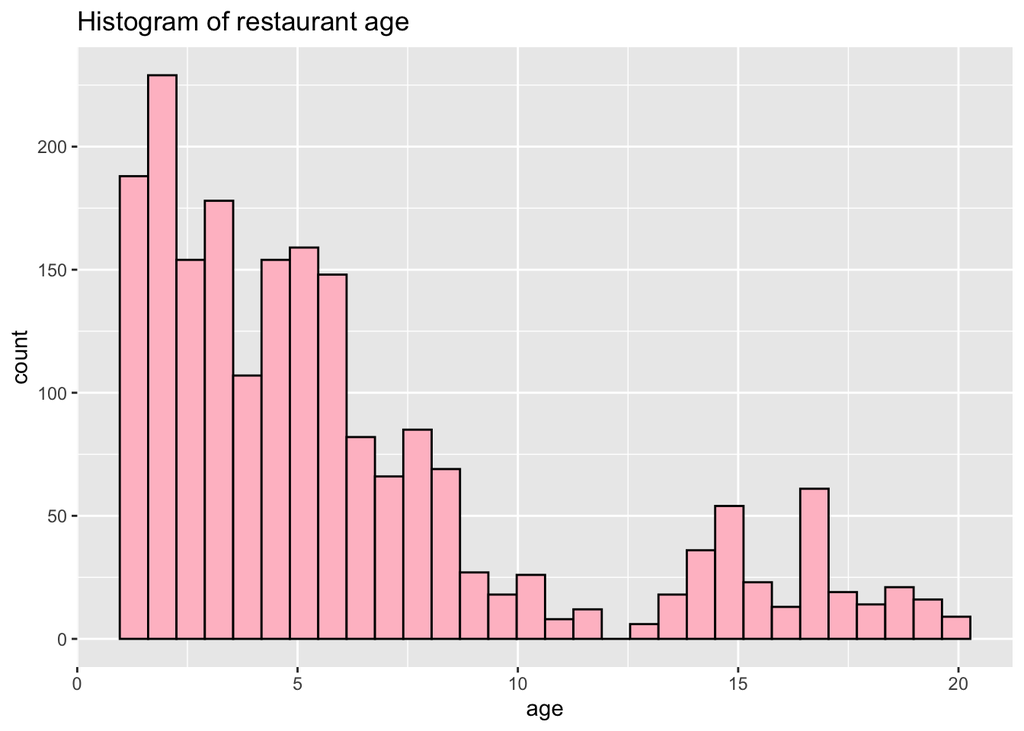

```r
#INCLUDE YOUR R CODE HERE
#time_length
mydata$open_date <- as.Date(mydata$open_date, format = "%m/%d/%Y")
mydata <- mydata %>%
  mutate(age = interval(ymd(mydata$open_date),ymd(as.Date('2015-01-01'))))
mydata$age <- time_length(mydata$age, "year")
ggplot(data = mydata, aes(age)) +
  geom_histogram(color = "black", fill = "pink", bins = 30) +
  labs(x = "age", title = "Histogram of restaurant age")
```

*3. Produce a pair-wise scatter plot of each *numerical* variable against the response. What do you notice from the plot? Make another plot for each of the numerical variable against the response that better shows the relationship between the two variables.* **(2 marks)**

INCLUDE YOUR ANSWER HERE

Based on the scatter plot, it appears that variables P1 through P8 are discrete variables that have already been converted to numeric values. It makes sense from the information that P1-P8 are either demographic, real estate or commercial information of the restaurants.

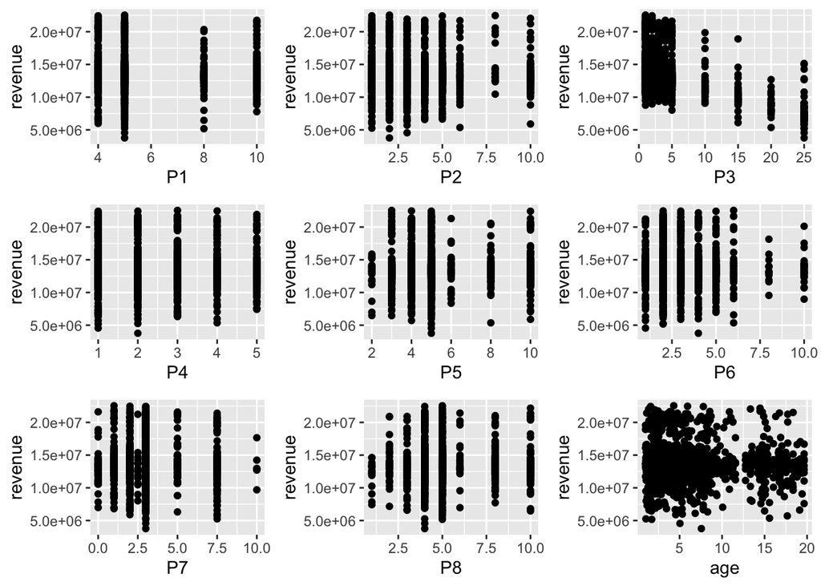

```r
#INCLUDE YOUR R CODE HERE
numerical_vars <- c("P1", "P2", "P3", "P4", "P5", "P6", "P7", "P8", "age")
response_var <- c("revenue")
plotP1 <- ggplot(mydata, aes(P1, revenue)) + geom_point()
plotP2 <- ggplot(mydata, aes(P2, revenue)) + geom_point()
plotP3 <- ggplot(mydata, aes(P3, revenue)) + geom_point()
plotP4 <- ggplot(mydata, aes(P4, revenue)) + geom_point()
plotP5 <- ggplot(mydata, aes(P5, revenue)) + geom_point()
plotP6 <- ggplot(mydata, aes(P6, revenue)) + geom_point()
plotP7 <- ggplot(mydata, aes(P7, revenue)) + geom_point()
plotP8 <- ggplot(mydata, aes(P8, revenue)) + geom_point()
plotage <- ggplot(mydata, aes(age, revenue)) + geom_point()
grid.arrange(plotP1, plotP2, plotP3, plotP4, plotP5, plotP6, plotP7, plotP8, plotage, ncol = 3)
```

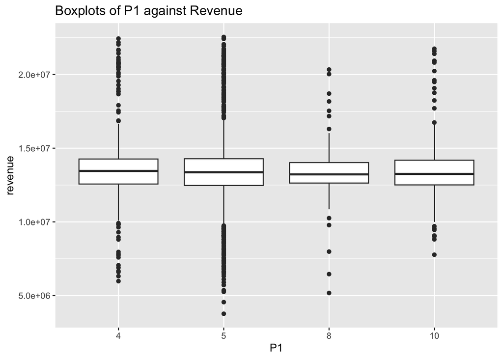

```r
#box plot is chosen to show the relationship between P1-P8 and revenue
ggplot(data = mydata, aes(x = as.factor(P1), y = revenue)) +
  geom_boxplot() +
  labs(x = "P1", title = "Boxplots of P1 against Revenue")
```

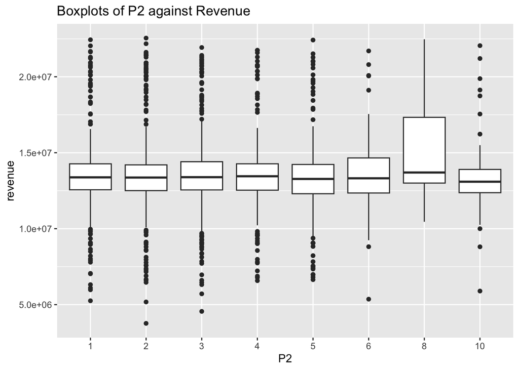

```r
ggplot(data = mydata, aes(x = as.factor(P2), y = revenue)) +
  geom_boxplot() +
  labs(x = "P2", title = "Boxplots of P2 against Revenue")
```

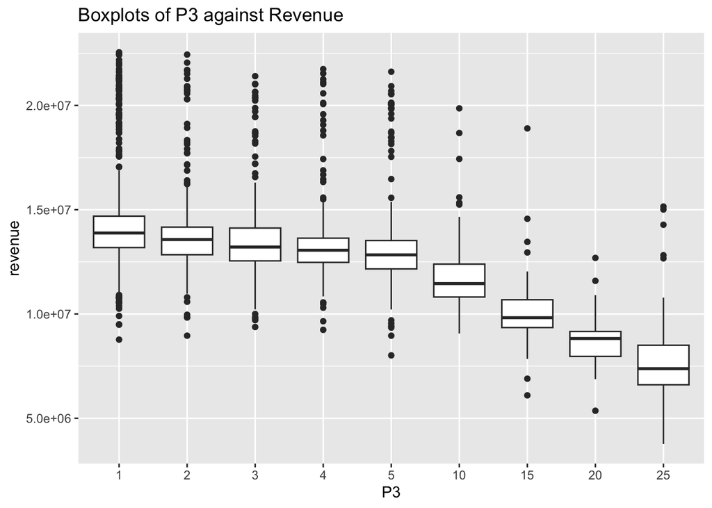

```r
ggplot(data = mydata, aes(x = as.factor(P3), y = revenue)) +
  geom_boxplot() +
  labs(x = "P3", title = "Boxplots of P3 against Revenue")
```

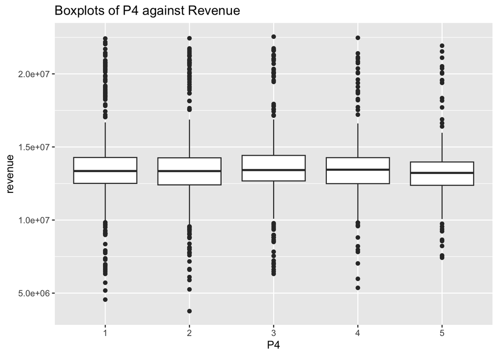

```r
ggplot(data = mydata, aes(x = as.factor(P4), y = revenue)) +
  geom_boxplot() +
  labs(x = "P4", title = "Boxplots of P4 against Revenue")
```

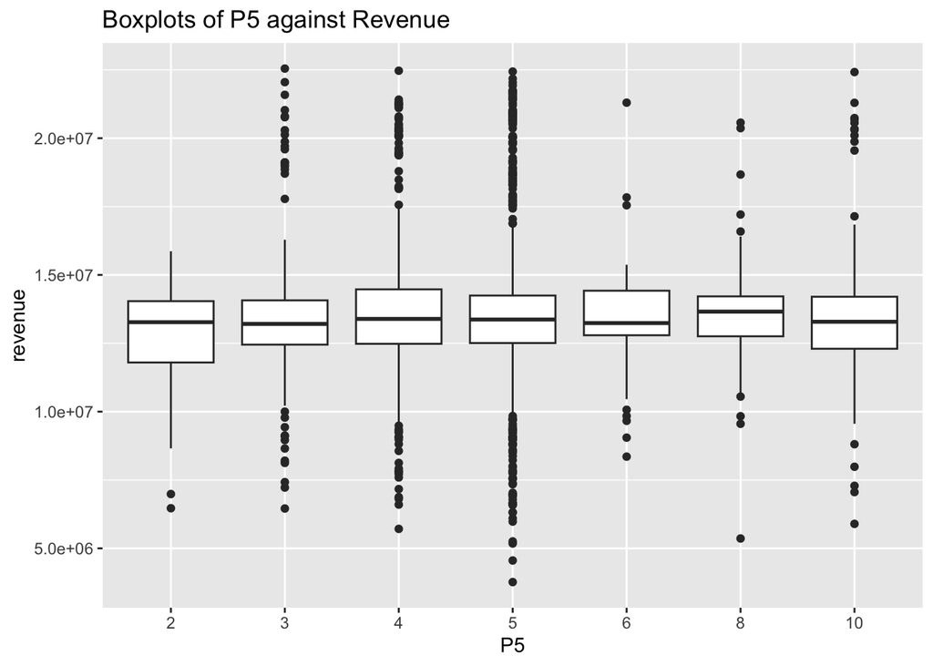

```r
ggplot(data = mydata, aes(x = as.factor(P5), y = revenue)) +
  geom_boxplot() +
  labs(x = "P5", title = "Boxplots of P5 against Revenue")
```

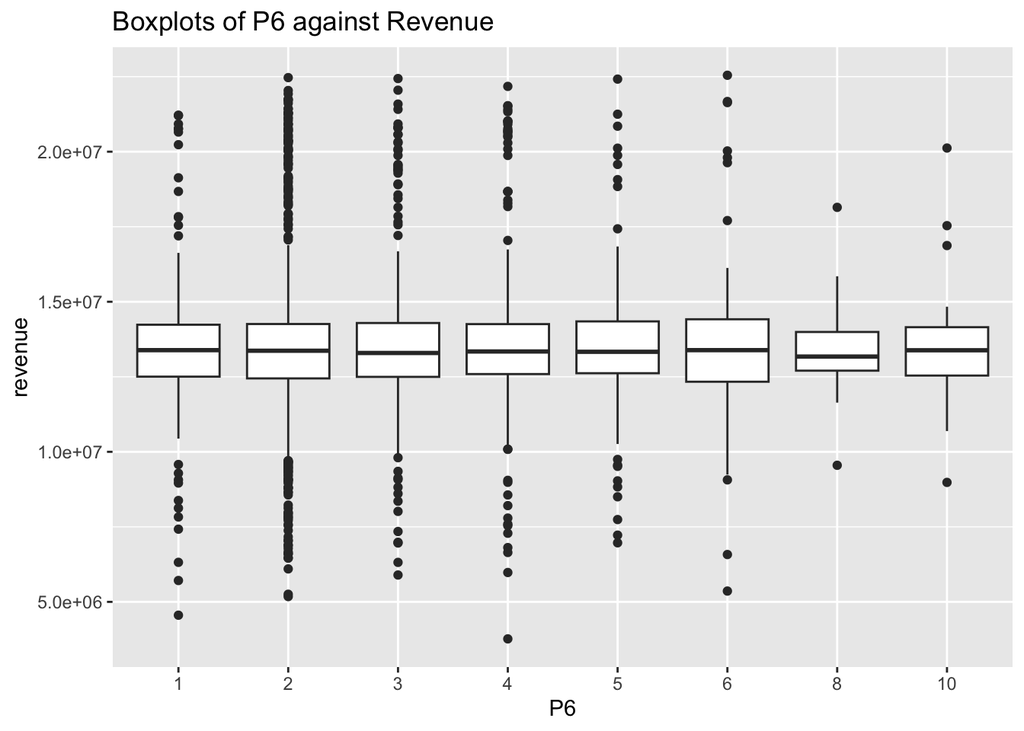

```r
ggplot(data = mydata, aes(x = as.factor(P6), y = revenue)) +
  geom_boxplot() +
  labs(x = "P6", title = "Boxplots of P6 against Revenue")
```

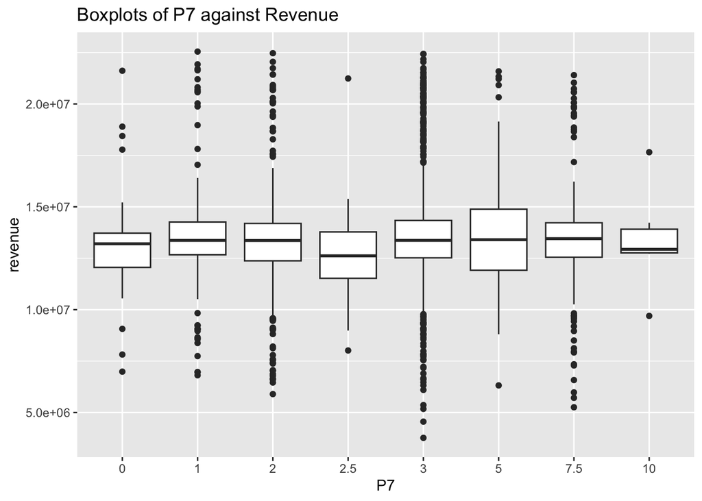

```r
ggplot(data = mydata, aes(x = as.factor(P7), y = revenue)) +
  geom_boxplot() +
  labs(x = "P7", title = "Boxplots of P7 against Revenue")
```

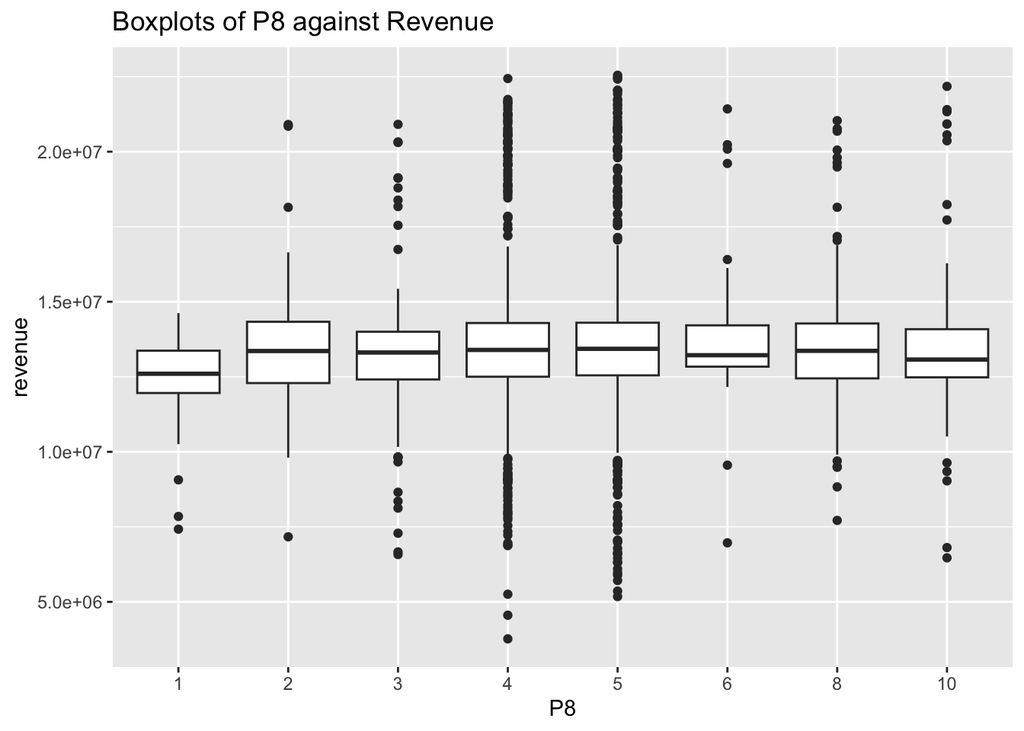

```r
ggplot(data = mydata, aes(x = as.factor(P8), y = revenue)) +
  geom_boxplot() +
  labs(x = "P8", title = "Boxplots of P8 against Revenue")
```

*4. Produce a numerical summary of all the variables in the data set.* **(1 mark)**

INCLUDE YOUR ANSWER HERE

```r
#INCLUDE YOUR R CODE HERE
summary(mydata)
```

```
##       id              open_date          type            P1
##  Length:2000        Min.   :1995-05-08   DT:  49   Min.   : 4.000
##  Class :character   1st Qu.:2007-05-05   FC:1133   1st Qu.: 5.000
##  Mode  :character   Median :2010-04-03   IL: 810   Median : 5.000
##                     Mean   :2008-11-09   MB:   8   Mean   : 5.488
##                     3rd Qu.:2012-05-04             3rd Qu.: 5.000
##                     Max.   :2014-01-04             Max.   :10.000
##        P2               P3              P4              P5
##  Min.   : 1.000   Min.   : 1.00   Min.   :1.000   Min.   : 2.000
##  1st Qu.: 2.000   1st Qu.: 1.00   1st Qu.:1.000   1st Qu.: 4.000
##  Median : 3.000   Median : 2.00   Median :2.000   Median : 5.000
##  Mean   : 3.294   Mean   : 3.69   Mean   :2.434   Mean   : 5.068
##  3rd Qu.: 4.000   3rd Qu.: 4.00   3rd Qu.:3.000   3rd Qu.: 5.000
##  Max.   :10.000   Max.   :25.00   Max.   :5.000   Max.   :10.000
##        P6               P7               P8            revenue
##  Min.   : 1.000   Min.   : 0.000   Min.   : 1.000   Min.   : 3766928
##  1st Qu.: 2.000   1st Qu.: 2.000   1st Qu.: 4.000   1st Qu.:12491753
##  Median : 2.000   Median : 3.000   Median : 5.000   Median :13365510
##  Mean   : 2.855   Mean   : 3.017   Mean   : 4.869   Mean   :13574725
##  3rd Qu.: 4.000   3rd Qu.: 3.000   3rd Qu.: 5.000   3rd Qu.:14270784
##  Max.   :10.000   Max.   :10.000   Max.   :10.000   Max.   :22546413
##       age
##  Min.   : 0.9918
##  1st Qu.: 2.6630
##  Median : 4.7479
##  Mean   : 6.1432
##  3rd Qu.: 7.6603
##  Max.   :19.6521
```

*5. Using the preliminary exploration in questions 1 to 4, do you observe any patterns in the data? Should you use the variable `id` and `open_date` in your predictive model? Explain your answer.* **(2 marks)**

INCLUDE YOUR ANSWER HERE

-There is one pattern between P3 and revenue can be observed in the data. When the value of P3 decrease, the revenue increase. There are no clear relationship between revenue and P1, P2, P4, P5, P6, P7, P8.

-In the common sense, the older restaurant will earn higher revenue. But it is not the case in this data. The revenue variety from low to high for both young and old restaurant.

-The variables ‘id’ and ‘open_date’ should not be used in the predictive model. The ‘id’ variable serves only to uniquely identify each observation in the data set and does not contain any information that is relevant to the revenue of the restaurants. Similarly, the “open_date” variable represents the day on which each restaurant was opened, which is a decision made by the owner and does not indicate anything about the revenue potential of the restaurant.

-Furthermore, the age of each restaurant was calculated by determining the time elapsed between its opening day and 1/1/2015, which is more relevant to predicting the restaurant’s revenue. Therefore, the ‘id’ and ‘open_date’ variables should be excluded from the predictive model, and instead using the age variable in predicting restaurant revenue.

```r
#INCLUDE YOUR R CODE HERE
```

### B Regression

*1. Remove the variables `id` and `open_date` from the data and select 70% of the observations to be used as the training data and the remaining data as the testing data.* **(1 mark)**

INCLUDE YOUR ANSWER HERE

```r
#INCLUDE YOUR R CODE HERE
set.seed(2023)
mydataB <- mydata %>% select(-c("id", "open_date"))
mydata_split <- initial_split(mydataB, prop = 0.7)
mydata_train <- training(mydata_split)
mydata_test <- testing(mydata_split)
```

*2. Use the training sample to estimate a multiple linear regression model for `revenue` in terms of all the predictors. Show the summary of this model fit. Discuss how well this model fits the data.* **(2 marks)**

INCLUDE YOUR ANSWER HERE

-The R-squared = 0.2904, it means that the model is just explained 29.04% of the data. Hence the model does not fits the data well.

```r
#INCLUDE YOUR R CODE HERE
revenue_lm <- lm(revenue ~., data = mydata_train)
summary(revenue_lm)
```

```
##
## Call:
## lm(formula = revenue ~ ., data = mydata_train)
##
## Residuals:
##      Min       1Q   Median       3Q      Max
## -5178104 -1119321  -449214   322596  8502225
##
## Coefficients:
##             Estimate Std. Error t value Pr(>|t|)
## (Intercept) 15286693     535976  28.521   <2e-16 ***
## typeFC       -379921     382850  -0.992    0.321
## typeIL       -365232     385870  -0.947    0.344
## typeMB      -1142233    1144174  -0.998    0.318
## P1            -45861      32455  -1.413    0.158
## P2              7451      29272   0.255    0.799
## P3           -277463      11755 -23.604   <2e-16 ***
## P4            -37250      42093  -0.885    0.376
## P5             15734      33906   0.464    0.643
## P6            -32776      36448  -0.899    0.369
## P7             46882      32929   1.424    0.155
## P8             -4907      33779  -0.145    0.885
## age           -17219      12428  -1.386    0.166
## ---
## Signif. codes:  0 '***' 0.001 '**' 0.01 '*' 0.05 '.' 0.1 ' ' 1
##
## Residual standard error: 2155000 on 1387 degrees of freedom
## Multiple R-squared:  0.2904, Adjusted R-squared:  0.2843
## F-statistic: 47.31 on 12 and 1387 DF,  p-value: < 2.2e-16
```

*3. Consider a model for `revenue` with all predictors *except* `type`. Show the summary of this model fit. Compare this model with the fitted model in question B2 using a hypothesis test. Explain the results of this test.* **(3 marks)**

INCLUDE YOUR ANSWER HERE

-The F-value = 0.4992 which is small, so there is no significant difference between two model and by adding the the variable “type” in model 1 does not provide any additional significant different to what is already captured by the other variables in model 2. -Because the F-value is the ratio between the difference of the residual sum of square between two models and the error variance. If two models are significantly different, the ratio will be large and if the ratio is not so large, it means 2 models are not significantly different.

```r
#INCLUDE YOUR R CODE HERE
revenue_lm_3 <-
  lm(revenue ~ P1 + P2 + P3 + P4 + P5 + P6 + P7 + P8 + age, data = mydata_train)
summary(revenue_lm_3)
```

```
##
## Call:
## lm(formula = revenue ~ P1 + P2 + P3 + P4 + P5 + P6 + P7 + P8 +
##     age, data = mydata_train)
##
## Residuals:
##      Min       1Q   Median       3Q      Max
## -5193014 -1121550  -457306   338142  8511464
##
## Coefficients:
##             Estimate Std. Error t value Pr(>|t|)
## (Intercept) 14905662     378177  39.415   <2e-16 ***
## P1            -45237      32422  -1.395    0.163
## P2              6820      29224   0.233    0.816
## P3           -277453      11745 -23.623   <2e-16 ***
## P4            -36032      42034  -0.857    0.391
## P5             15384      33885   0.454    0.650
## P6            -31944      36388  -0.878    0.380
## P7             47031      32901   1.429    0.153
## P8             -5836      33751  -0.173    0.863
## age           -15045      12256  -1.228    0.220
## ---
## Signif. codes:  0 '***' 0.001 '**' 0.01 '*' 0.05 '.' 0.1 ' ' 1
##
## Residual standard error: 2154000 on 1390 degrees of freedom
## Multiple R-squared:  0.2897, Adjusted R-squared:  0.2851
## F-statistic: 62.98 on 9 and 1390 DF,  p-value: < 2.2e-16
```

```r
anova(revenue_lm, revenue_lm_3)
```

```
## Analysis of Variance Table
##
## Model 1: revenue ~ type + P1 + P2 + P3 + P4 + P5 + P6 + P7 + P8 + age
## Model 2: revenue ~ P1 + P2 + P3 + P4 + P5 + P6 + P7 + P8 + age
##   Res.Df        RSS Df   Sum of Sq      F Pr(>F)
## 1   1387 6.4417e+15
## 2   1390 6.4486e+15 -3 -6.9558e+12 0.4992 0.6829
```

*4. Which of the two regression models considered (in questions B2 and B3) is best at predicting new records? Explain your answer.* **(2 marks)**

INCLUDE YOUR ANSWER HERE

-From the F-value in question B3, we can say that there is no different between 2 models. However, it does not measure the predictive accuracy of the model and we cannot simply choose the simpler one for prediction purpose. So other metrics RMSE, MAE, MAPE, MPE are employed to compare the predicted values from the model with the actual observed values in the data.

-Between two models revenue_lm and revenue_lm_3, revenue_lm_3 would be better at predicting new records. Because it is priority to use simpler model when there is no significant difference between two model, and it works better with most of the data although it struggle dealing with the outliers or extreme values.

-However, it is also suggested that further investigation is necessary and other methods should be employed to consider other appropriate models. At the same time, the outliers or extreme values need to be considered when choosing the appropriate models for prediction.

```r
#INCLUDE YOUR R CODE HERE
imap_dfr(list("revenue_lm_3" = revenue_lm_3 ,
              "revenue_lm" = revenue_lm),
         ~ {
           mydata_test %>%
             mutate(.pred = predict(.x, .),
                    .model = .y)
         }) %>%
  group_by(.model) %>%
  metric_set(rmse, mae, mape, mpe)(., revenue, .pred) %>%
  pivot_wider(.metric, names_from = .model, values_from = .estimate)
```

```
## # A tibble: 4 × 3
##   .metric revenue_lm revenue_lm_3
##   <chr>        <dbl>        <dbl>
## 1 rmse    2270035.     2272683.
## 2 mae     1490979.     1489522.
## 3 mape         10.5         10.5
## 4 mpe          -2.32        -2.34
```

### C Subset selection

*1. Consider the model in question B2 as the full model. Perform a backward elimination using BIC. Report the final selected model using this process.* **(2 marks)**

INCLUDE YOUR ANSWER HERE

-The final selected model using a backward elimination using BIC is revenue = 14596811 - 277053*P3

```r
#INCLUDE YOUR R CODE HERE
step <- stats::step
null <- lm(revenue ~ 1, data = mydata_train)
scope <- list(lower = formula(null),
              upper = formula(revenue_lm))
step(revenue_lm,
     scope = scope,
     direction = "backward",
     k = log(nrow(mydata_train)))
```

```
## Start:  AIC=40914.45
## revenue ~ type + P1 + P2 + P3 + P4 + P5 + P6 + P7 + P8 + age
##
##        Df  Sum of Sq        RSS   AIC
## - type  3 6.9558e+12 6.4486e+15 40894
## - P8    1 9.8007e+10 6.4418e+15 40907
## - P2    1 3.0092e+11 6.4420e+15 40907
## - P5    1 1.0001e+12 6.4427e+15 40907
## - P4    1 3.6371e+12 6.4453e+15 40908
## - P6    1 3.7555e+12 6.4454e+15 40908
## - age   1 8.9154e+12 6.4506e+15 40909
## - P1    1 9.2732e+12 6.4509e+15 40909
## - P7    1 9.4139e+12 6.4511e+15 40909
## <none>               6.4417e+15 40914
## - P3    1 2.5875e+15 9.0291e+15 41380
##
## Step:  AIC=40894.23
## revenue ~ P1 + P2 + P3 + P4 + P5 + P6 + P7 + P8 + age
##
##        Df  Sum of Sq        RSS   AIC
## - P8    1 1.3871e+11 6.4488e+15 40887
## - P2    1 2.5268e+11 6.4489e+15 40887
## - P5    1 9.5624e+11 6.4496e+15 40887
## - P4    1 3.4090e+12 6.4520e+15 40888
## - P6    1 3.5753e+12 6.4522e+15 40888
## - age   1 6.9908e+12 6.4556e+15 40888
## - P1    1 9.0314e+12 6.4577e+15 40889
## - P7    1 9.4798e+12 6.4581e+15 40889
## <none>               6.4486e+15 40894
## - P3    1 2.5889e+15 9.0375e+15 41360
##
## Step:  AIC=40887.01
## revenue ~ P1 + P2 + P3 + P4 + P5 + P6 + P7 + age
##
##        Df  Sum of Sq        RSS   AIC
## - P2    1 2.4476e+11 6.4490e+15 40880
## - P5    1 1.0137e+12 6.4498e+15 40880
## - P4    1 3.3685e+12 6.4521e+15 40880
## - P6    1 3.6037e+12 6.4524e+15 40881
## - age   1 6.9921e+12 6.4558e+15 40881
```

[output cut: 59 more lines]

```
##
## Step:  AIC=40848.99
## revenue ~ P1 + P3
##
##        Df  Sum of Sq        RSS   AIC
## - P1    1 9.8372e+12 6.4837e+15 40844
## <none>               6.4739e+15 40849
## - P3    1 2.6041e+15 9.0780e+15 41315
##
## Step:  AIC=40843.87
## revenue ~ P3
##
##        Df  Sum of Sq        RSS   AIC
## <none>               6.4837e+15 40844
## - P3    1 2.5944e+15 9.0781e+15 41308
```

```
##
## Call:
## lm(formula = revenue ~ P3, data = mydata_train)
##
## Coefficients:
## (Intercept)           P3
##    14596811      -277053
```

*2. Again consider the same model question B2 and perform now a step-wise regression using AIC. How is this model different to the one selected in question C1?* **(2 marks)**

INCLUDE YOUR ANSWER HERE

-The final selected model using a step-wise regression using AIC is revenue = 14714499 - 278036*P3 - 46884*P1 + 47557*P7.

-While the model chose by a backward elimination using BIC just contains 1 variable P3, the model chosen by a step-wise regression using AIC contains 3 variables P1, P3 and P7.

```r
#INCLUDE YOUR R CODE HERE
step(null, scope = scope, direction = "both", k = 2)
```

```
## Start:  AIC=41302.58
## revenue ~ 1
##
##        Df  Sum of Sq        RSS   AIC
## + P3    1 2.5944e+15 6.4837e+15 40833
## <none>               9.0781e+15 41303
## + age   1 1.2808e+13 9.0653e+15 41303
## + P4    1 1.2755e+13 9.0654e+15 41303
## + P7    1 8.4299e+12 9.0697e+15 41303
## + P5    1 4.3581e+12 9.0738e+15 41304
## + P6    1 2.8914e+12 9.0752e+15 41304
## + P1    1 1.7427e+11 9.0780e+15 41305
## + P8    1 8.3364e+10 9.0780e+15 41305
## + P2    1 6.9208e+10 9.0781e+15 41305
## + type  3 4.6435e+12 9.0735e+15 41308
##
## Step:  AIC=40833.38
## revenue ~ P3
##
##        Df  Sum of Sq        RSS   AIC
## + P1    1 9.8372e+12 6.4739e+15 40833
## + P7    1 9.8174e+12 6.4739e+15 40833
## <none>               6.4837e+15 40833
## + age   1 7.6079e+12 6.4761e+15 40834
## + P4    1 3.8116e+12 6.4799e+15 40835
## + P6    1 3.2216e+12 6.4805e+15 40835
## + P5    1 1.6164e+12 6.4821e+15 40835
## + P8    1 2.9135e+11 6.4834e+15 40835
## + P2    1 1.6514e+11 6.4836e+15 40835
## + type  3 4.5219e+12 6.4792e+15 40838
## - P3    1 2.5944e+15 9.0781e+15 41303
##
## Step:  AIC=40833.25
## revenue ~ P3 + P1
##
##        Df  Sum of Sq        RSS   AIC
## + P7    1 9.7249e+12 6.4642e+15 40833
## <none>               6.4739e+15 40833
## - P1    1 9.8372e+12 6.4837e+15 40833
## + age   1 7.7786e+12 6.4661e+15 40834
```

[output cut: 8 more lines]

```
## Step:  AIC=40833.15
## revenue ~ P3 + P1 + P7
##
##        Df  Sum of Sq        RSS   AIC
## <none>               6.4642e+15 40833
## - P7    1 9.7249e+12 6.4739e+15 40833
## - P1    1 9.7447e+12 6.4739e+15 40833
## + age   1 7.4188e+12 6.4567e+15 40834
## + P6    1 3.3954e+12 6.4608e+15 40834
## + P4    1 3.2598e+12 6.4609e+15 40834
## + P5    1 1.2331e+12 6.4629e+15 40835
## + P2    1 2.2554e+11 6.4639e+15 40835
## + P8    1 1.7558e+11 6.4640e+15 40835
## + type  3 4.5990e+12 6.4596e+15 40838
## - P3    1 2.6054e+15 9.0695e+15 41305
```

```
##
## Call:
## lm(formula = revenue ~ P3 + P1 + P7, data = mydata_train)
##
## Coefficients:
## (Intercept)           P3           P1           P7
##    14714499      -278036       -46884        47557
```

### D Regularization

*1. Make an appropriate transformation to the training data for regularization methods. From this transformed training dataset, create a 5-fold cross validation dataset.* **(2 marks)**

INCLUDE YOUR ANSWER HERE

```r
#INCLUDE YOUR R CODE HERE
mydata_train_recipe <- recipe(revenue ~., data = training(mydata_split)) %>%
  step_normalize(all_numeric_predictors()) %>%
  step_dummy(all_nominal_predictors()) %>%
  step_zv(all_predictors()) %>%
# step_log(all_outcomes(), base = 10) %>%
  prep()

mydata_training <- mydata_train_recipe %>%
  bake(new_data = NULL)

mydata_testing <- mydata_train_recipe %>%
  bake(new_data = testing(mydata_split))

revenue_fold <- vfold_cv(mydata_training, v = 5)
```

*2. Using the dataset from question D1, select the optimal tuning parameter $\lambda$ for lasso regression using the average root mean square error. You can use the search range for $\lambda$ to be $[1, 10^{10}]$ (or in code use `10^seq(0, 10, length = 50)`). You should *not* use any convenience function like `cv.glmnet` to select $\lambda$.* **(2 marks)**

INCLUDE YOUR ANSWER HERE

```r
#INCLUDE YOUR R CODE HERE
lambda_vec <- 10 ^ seq(0, 10, length.out = 50)

cv_glmnet_to_revenue <- function(alpha) {
  revenue_fold %>%
    mutate(metrics = map(splits, function(.split) {
      fold_train_data <- training(.split)
      fold_fit <- glmnet(
        x = fold_train_data %>%
          select(-revenue),
        y = fold_train_data$revenue,
        alpha = alpha,
        lambda = lambda_vec
      )
      fold_test_data <- testing(.split)
      fold_preds <- fold_fit %>%
        predict(as.matrix(select(fold_test_data, -revenue))) %>%
        as.data.frame() %>%
        add_column(revenue = fold_test_data$revenue) %>%
        pivot_longer(-revenue, values_to = ".pred", names_to = "name") %>%
        left_join(tibble(
          name = paste0("s", 1:length(lambda_vec) - 1),
          lambda = rev(lambda_vec)
        ),
        by = "name")
      fold_preds %>%
        group_by(name, lambda) %>%
        metric_set(rmse)(., revenue, .pred) %>%
        select(-.estimator) %>%
        arrange(.metric, lambda)
    })) %>%
    unnest(metrics) %>%
    group_by(name, .metric) %>%
    summarise(
      alpha = alpha,
      lambda = unique(lambda),
      mean = mean(.estimate),
      se = sd(.estimate),
      .groups = "drop"
    )
}
lasso_tuning_res <- cv_glmnet_to_revenue(alpha = 1)
lasso_tuning_res
```

```
## # A tibble: 50 × 6
##    name  .metric alpha       lambda     mean      se
##    <chr> <chr>   <dbl>        <dbl>    <dbl>   <dbl>
##  1 s0    rmse        1 10000000000  2544152. 135574.
##  2 s1    rmse        1  6250551925. 2544152. 135574.
##  3 s10   rmse        1    91029818. 2544152. 135574.
##  4 s11   rmse        1    56898660. 2544152. 135574.
##  5 s12   rmse        1    35564803. 2544152. 135574.
##  6 s13   rmse        1    22229965. 2544152. 135574.
##  7 s14   rmse        1    13894955. 2544152. 135574.
##  8 s15   rmse        1     8685114. 2544152. 135574.
##  9 s16   rmse        1     5428675. 2544152. 135574.
## 10 s17   rmse        1     3393222. 2544152. 135574.
## # … with 40 more rows
## # ℹ Use `print(n = ...)` to see more rows
```

```r
lasso_tuning_res_min <- lasso_tuning_res %>%
  group_by(.metric) %>%
  filter(mean == min(mean))

lasso_tuning_res_min
```

```
## # A tibble: 1 × 6
## # Groups:   .metric [1]
##   name  .metric alpha lambda     mean      se
##   <chr> <chr>   <dbl>  <dbl>    <dbl>   <dbl>
## 1 s25   rmse        1 79060. 2152356. 141339.
```

```r
lambda_chose <- lasso_tuning_res_min %>% pull(lambda)
```

- The purpose of the below code section is to select an appropriate range of lambda values for Lasso regression. By plotting the range of lambda values against the root mean squared error (RMSE), we observed that a higher range of lambda values is suitable when the response variable (revenue) is not log-transformed. However, if the response variable is log-transformed, a smaller range of lambda values is more appropriate.
- When the response variable is not log-transformed, the value of revenue may be relatively high compared to the predictor variable, resulting in higher potential values for the regression coefficients. In such cases, a higher value of lambda can fit in and help to constrain the size of the coefficients. This approach ensures that the coefficients will be fit to the range of the response variable and constrained accordingly.

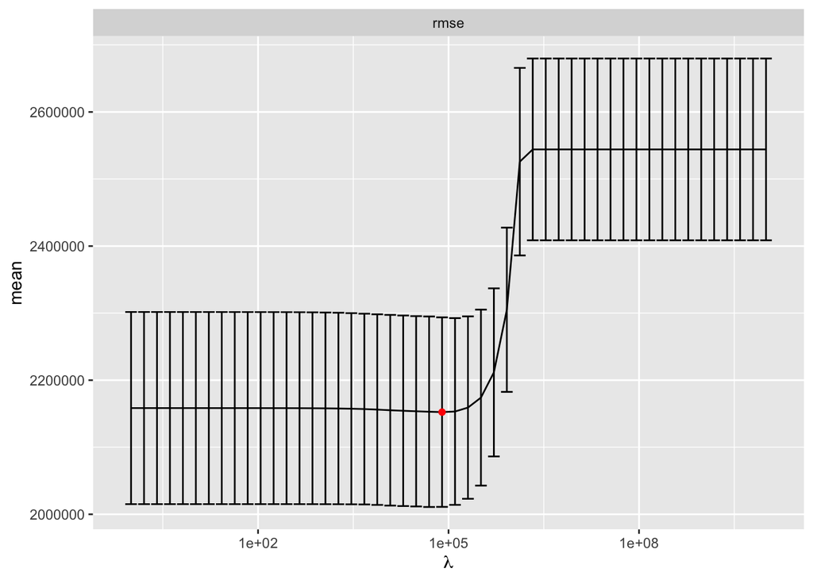

```r
mydata_tuning_lasso <- cv_glmnet_to_revenue(alpha = 1)

mydata_tuning_lasso_min <- mydata_tuning_lasso %>%
  group_by(.metric) %>%
  filter(mean == min(mean))

mydata_tuning_lasso %>%
  ggplot(aes(lambda, mean)) +
  geom_errorbar(aes(ymin = mean - se,
                    ymax = mean + se)) +
  geom_line() +
  geom_point(data = mydata_tuning_lasso_min,
             color = 'red') +
  facet_wrap( ~ .metric, scales = "free") +
  scale_x_log10(name = latex2exp::TeX("\\lambda"))
```

*3. Fit an elastic net model with optimal $\lambda$ and $\alpha$ selected by cross validation root mean square error using the dataset from question D2. Recall that $\alpha \in [0, 1]$ (in code you can use `seq(0, 1, length = 21)`). Remember that you need to find a combination of $\lambda$ and $\alpha$ that minimises the average root mean square error. Again don’t use any convenience (i.e. one line) function. Discuss the results.* **(4 marks)**

```r
alpha_vec <- seq(0, 1, length.out = 21)
combine_result <- tibble()
for (i in 1:length(alpha_vec)) {
  combine_result <-
    bind_rows(combine_result, cv_glmnet_to_revenue(alpha_vec[i]))
}
min_RMSE <- combine_result %>%
  group_by(.metric) %>%
  filter(mean == min(mean))
min_RMSE
```

```
## # A tibble: 1 × 6
## # Groups:   .metric [1]
##   name  .metric alpha lambda     mean      se
##   <chr> <chr>   <dbl>  <dbl>    <dbl>   <dbl>
## 1 s25   rmse        1 79060. 2152356. 141339.
```

```r
elastic_best_lamda <- min_RMSE$lambda
elastic_best_alpha <- min_RMSE$alpha
elasticreg <- glmnet(
  x = mydata_training %>%
    select(-c(revenue)),
  y = mydata_training$revenue,
  alpha = elastic_best_alpha,
  lambda = elastic_best_lamda
)
coef(elasticreg)
```

```
## 13 x 1 sparse Matrix of class "dgCMatrix"
##                        s0
## (Intercept) 13562412.7879
## P1              -411.3463
## P2                 .
## P3          -1282743.6893
## P4                 .
## P5                 .
## P6                 .
## P7              4321.8655
## P8                 .
## age                .
## type_FC            .
## type_IL            .
## type_MB            .
```

## E. Conclusion

*1. What variables are important (or not important) in modelling the response? Explain your answer.* **(2 marks)**

INCLUDE YOUR ANSWER HERE

- The variables “ID” and “open_date” were excluded from the model because they do not significantly contribute to predicting whether a restaurant will generate higher revenue or not.
- From the plot, the trend between the P3 and revenue was detected, the correlation between P3 and revenue is high. It indicated that P3 can be potentially important variable in the model.
- The “type” variable was considered to be included or excluded of the model. The F-test was employed and shown that there was no significant between the model including “type”(revenue_lm) and the model exclude “type”(Revenue_lm_3). Then, the other metrics such as RMSE, MAE, MAPE and MPE were used to measure the accuracy of the predictive value between two models. The result shown that the revenue_lm_3 perform better with almost of the data but it struggle in dealing with the outliers or extreme value. Hence, the other variable selection methods were used to find an appropriate model.
- Then the backward elimination and step regression were employed. In the backward elimination, it suggested that only P3 should be included in the model. While in the step regression, it suggested that P1, P3 and P7 should be included in the model.
- From the analysis, P3 is the most important variable in the model. The other variables should be considered including in the model is P1 and P7. The “id”, “open_date”, “type”, “P2”, “P4”, “P5”, “P6”,“P8” can be excluded from the model.

```r
#INCLUDE YOUR R CODE HERE
```

*2. What model would you recommend to TFI for predicting new records? Give statistical reasons for your recommendation.* **(2 marks)**

```r
#INCLUDE YOUR R CODE HERE
predict <- stats::predict
#calculate the root mean squared error between the true data and the predict value from
#the lasso regression
pred_lasso <- predict(elasticreg,
                      s = elastic_best_lamda,
                      newx = as.matrix(mydata_testing %>%
                                         select(-c(revenue))))
rmse_vec(as.vector(pred_lasso), mydata_testing$revenue)
```

```
## [1] 2261185
```